# Session 2

21/10/2021

## Feedback assignment 1 (1)

- don’t include `install.packages()`, do include `library()`.
- Give the objects we ask you to create exactly the same name as in the assignment.
  - R is Capital-sensitive
- Don’t forget to save the result as an object.

## Know what to look for

Data type =  
elements

- Character
- Numeric
- Integer
- Logical

Data structure =  
how elements are ordered

- Factor
- Vector
- Matrix
- List
- Data frame

## Session 2: Data exploration

## Get to know the data (1)

What kind of data did we get?

- What structure has the object?
- What data types are contained within the object?
- Do the structure and data types make sense?
- Are there NA-values or incorrect values?

Any fishy business?

[figure not shown]

## Plotting …

[figure not shown]

## … can be very useful.

[figure not shown]

## Get to know the data (2)

What is the quality of the data? How should we interpret it?

Statistical tests:

- Normality?
- Outliers?
- …

Apply necessary transformation if needed!

## Before we start

If you have difficulties with any aspects of working with R, don’t hesitate to say so!

[figure not shown]

## Exercises for today

- Check the structure of the data
- Check NA and incorrect values
- Visualize your data
- Perform outlier analysis
- Check distribution of variables
- Apply transformations to normalize variables
- Apply transformations to linearize relationships

## Update your package

Update your “edcpR” pacakge using the script provided on Toledo `update-edcpR.R`

Find useful tips and function suggestions on the cheat-sheet vignette

```r
browseVignettes(package = "edcpR")
```

## Exercises: part 1 (30 min)

Use the “varechem_s2” datast in the course package.

- Check the structure and data type of the data (and change in R if necessary)
  - **Extra**: Try to assign meaningful levels for the variable *Managementtype*
- Check NA and incorrect values (and change in R if necessary)
  - **TIP**: anyNA(), complete.cases(), …
  - Calculate summary metrics (min, max, mean, …) to check for anomalies
- Visualize your data
  - Try different types of graphs (scatterplot, histogram, boxplot…)

## Check structure of data (1)

```r
library(edcpR)
#Load in data
data(varechem_s2, package = "edcpR")

# First it is a good idea to take a look at the object in the Environment window

# Take a look at the data, does it seem to be loaded in alright?
head(varechem_s2)
```

```
##      P     K   Mg    S    Fe   Zn  pH     Ca Managementtype  Landuse
## 1 47.4 165,9 64.3 42.3 200.1 2.45 4.1  436.1              4 Hayfield
## 2 32.3  73,7 52.5 25.5 204.4 2.32 6.0 7778.0              4 Hayfield
## 3 64.9 251,1 59.7 52.9 170.0 1.98 4.5  517.6              4 Hayfield
## 4 22.7  43,6 25.7 14.9   8.4 0.92 5.9  758.5              4 Haypastu
## 5 26.5  61,1 37.0 21.4  81.4 1.87 4.6  609.1              1  Pasture
## 6 24.6  78,7   NA 25.3 132.0 1.78 7.7 1004.3              4  Pasture
```

## Check structure of data (2)

```r
tail(varechem_s2)
```

```
##       P     K    Mg    S   Fe   Zn  pH    Ca Managementtype  Landuse
## 19 62.0 171,4  94.9 33.8  2.5 0.41 3.1 654.1              3  Pasture
## 20 54.5 180,6 125.8 39.5  3.0 0.49 2.7 219.3              3 Hayfield
## 21 67.7 207,1 209.1 58.1 35.4 1.55 5.0 973.3              1 Haypastu
## 22 50.6 151,7  64.8 30.2  2.3 0.39 3.6 648.4              1 Haypastu
## 23 60.8 233,7 127.2 40.7  4.4 0.65 2.8 487.6              1 Haypastu
## 24 73.5 260,5 105.3 42.5  2.4 0.38 3.5 658.2              3 Hayfield
```

## Check structure of data (3)

```r
# Same information as in Environment window when clicking the blue arrow
str(varechem_s2)
```

```
## 'data.frame':    24 obs. of  10 variables:
##  $ P             : num  47.4 32.3 64.9 22.7 26.5 24.6 48.4 62.8 55.8 32.7 ...
##  $ K             : chr  "165,9" "73,7" "251,1" "43,6" ...
##  $ Mg            : num  64.3 52.5 59.7 25.7 37 ...
##  $ S             : num  42.3 25.5 52.9 14.9 21.4 25.3 46.9 48.6 35.9 31.1 ...
##  $ Fe            : num  200.1 204.4 170 8.4 81.4 ...
##  $ Zn            : num  2.45 2.32 1.98 0.92 1.87 1.78 1.54 1.48 1.99 0.95 ...
##  $ pH            : num  4.1 6 4.5 5.9 4.6 7.7 4.5 7.1 7.5 6.2 ...
##  $ Ca            : num  436 7778 518 758 609 ...
##  $ Managementtype: int  4 4 4 4 1 4 4 4 1 4 ...
##  $ Landuse       : chr  "Hayfield" "Hayfield" "Hayfield" "Haypastu" ...
```

## Check structure of data (4)

```r
# substitute the "," in the character string with "."
varechem_s2$K <- gsub(",", ".", varechem_s2$K)

# Convert the data type to numeric
class(varechem_s2$K) <- "numeric"
# OR
varechem_s2$K <- as.numeric(varechem_s2$K)

# Or compact in one step:
varechem_s2$K <- as.numeric(gsub(",", ".", varechem_s2$K))
```

## Check structure of data (5)

```r
# The managementtype data type is integer, which doesn't make sense. It should be a factor
varechem_s2$Managementtype <- as.factor(varechem_s2$Managementtype)
# OR
class(varechem_s2$Managementtype) <-  "factor"

# Check levels of factor
levels(varechem_s2$Managementtype)
```

```
## [1] "1" "2" "3" "4"
```

```r
# We could assign levels to this column
levels(varechem_s2$Managementtype) <- c("Natural", "Agricultural", "Mixed", "Unknown")
levels(varechem_s2$Managementtype)
```

```
## [1] "Natural"      "Agricultural" "Mixed"        "Unknown"
```

## NA and incorrect values (1)

```r
# Test if any values are NA
anyNA(varechem_s2) # Tests if there are any NA values
```

```
## [1] TRUE
```

```r
head(is.na(varechem_s2)) # Location where output is TRUE is NA
```

```
##          P     K    Mg     S    Fe    Zn    pH    Ca Managementtype Landuse
## [1,] FALSE FALSE FALSE FALSE FALSE FALSE FALSE FALSE          FALSE   FALSE
## [2,] FALSE FALSE FALSE FALSE FALSE FALSE FALSE FALSE          FALSE   FALSE
## [3,] FALSE FALSE FALSE FALSE FALSE FALSE FALSE FALSE          FALSE   FALSE
## [4,] FALSE FALSE FALSE FALSE FALSE FALSE FALSE FALSE          FALSE   FALSE
## [5,] FALSE FALSE FALSE FALSE FALSE FALSE FALSE FALSE          FALSE   FALSE
## [6,] FALSE FALSE  TRUE FALSE FALSE FALSE FALSE FALSE          FALSE   FALSE
```

## NA and incorrect values (2)

```r
!complete.cases(varechem_s2) # "!" is a NOT operator. This line gives if row is NOT complete.
```

```
##  [1] FALSE FALSE FALSE FALSE FALSE  TRUE FALSE FALSE FALSE FALSE FALSE FALSE
## [13] FALSE FALSE FALSE FALSE FALSE FALSE FALSE FALSE FALSE FALSE FALSE FALSE
```

```r
# The 6th element is true, so the 6th row is incomplete
varechem_s2[!complete.cases(varechem_s2),]
```

```
##      P    K Mg    S  Fe   Zn  pH     Ca Managementtype Landuse
## 6 24.6 78.7 NA 25.3 132 1.78 7.7 1004.3        Unknown Pasture
```

## NA and incorrect values (3)

```r
# Get max, min, median, mean for columns, in this case the fifth column
max(varechem_s2$Fe) # column
```

```
## [1] 204.4
```

```r
max(varechem_s2[5]) # column
```

```
## [1] 204.4
```

```r
max(varechem_s2[,5]) # column
```

```
## [1] 204.4
```

```r
max(varechem_s2[5,]) # row, doesn't work because different data types in one row.
```

## NA and incorrect values (4)

```r
max <- apply(varechem_s2, 2, max) # 2 = apply function over each column
max # NA as maximum is not very informative, max for factors is most occurring value.
```

```
##              P              K             Mg              S             Fe
##         "73.5"        "313.8"             NA        "486.0"        "204.4"
##             Zn             pH             Ca Managementtype        Landuse
##         "2.45"          "7.7"       "7778.0"      "Unknown"      "Pasture"
```

```r
max <- apply(varechem_s2, 2, function(x){max(x, na.rm = TRUE)})
max # Perfect
```

```
##              P              K             Mg              S             Fe
##         "73.5"        "313.8"        "209.1"        "486.0"        "204.4"
##             Zn             pH             Ca Managementtype        Landuse
##         "2.45"          "7.7"       "7778.0"      "Unknown"      "Pasture"
```

```r
min <- apply(varechem_s2, 2, function(x){min(x, na.rm = TRUE)}) # Minimum
```

## NA and incorrect values (5)

```r
plot(max)
points(min, col = "red")
```

## NA and incorrect values (6)

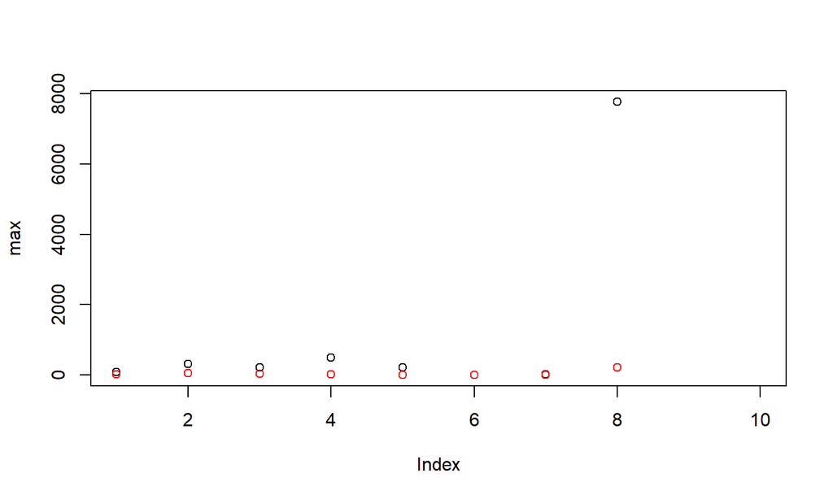

## NA and incorrect values (7)

```r
colnames(varechem_s2)[8]
```

```
## [1] "Ca"
```

```r
varechem_s2$Ca
```

```
##  [1]  436.1 7778.0  517.6  758.5  609.1 1004.3  499.6  956.6 1250.1  871.4
## [11]  540.7  512.2  356.7  394.6  258.9  368.2  546.3  484.8  654.1  219.3
## [21]  973.3  648.4  487.6  658.2
```

## NA and incorrect values (8)

```r
varechem_s2[2,8]
```

```
## [1] 7778
```

```r
# If it was a bigger dataframe, we wouldn't want to scan the whole table for that one value
head(varechem_s2 == 7778.0)
```

```
##          P     K    Mg     S    Fe    Zn    pH    Ca Managementtype Landuse
## [1,] FALSE FALSE FALSE FALSE FALSE FALSE FALSE FALSE          FALSE   FALSE
## [2,] FALSE FALSE FALSE FALSE FALSE FALSE FALSE  TRUE          FALSE   FALSE
## [3,] FALSE FALSE FALSE FALSE FALSE FALSE FALSE FALSE          FALSE   FALSE
## [4,] FALSE FALSE FALSE FALSE FALSE FALSE FALSE FALSE          FALSE   FALSE
## [5,] FALSE FALSE FALSE FALSE FALSE FALSE FALSE FALSE          FALSE   FALSE
## [6,] FALSE FALSE    NA FALSE FALSE FALSE FALSE FALSE          FALSE   FALSE
```

```r
varechem_s2[varechem_s2 == 7778.0] <- 777.8
```

## Visualize your data (1)

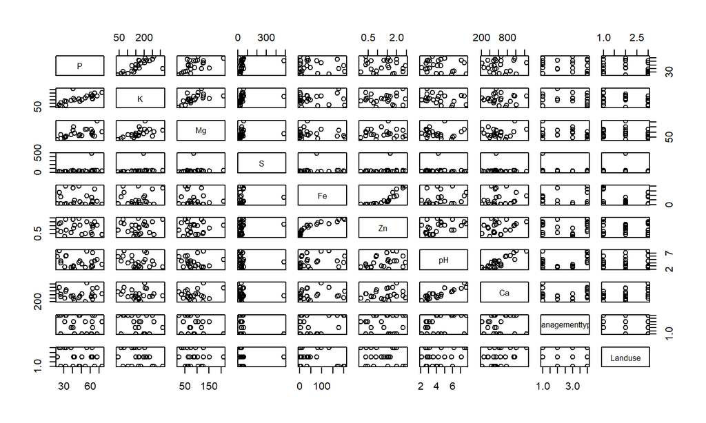

```r
# pairs(varechem_s2)
plot(varechem_s2)
```

## Visualize your data (2)

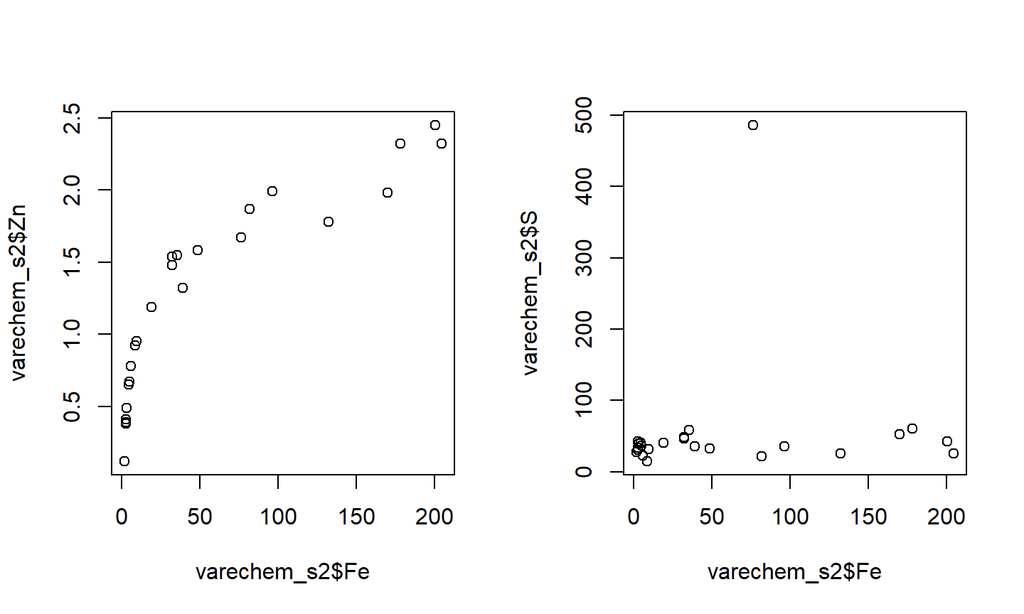

```r
par(mfrow=c(1,2))
plot(varechem_s2$Fe, varechem_s2$Zn) # Nice relationship
plot(varechem_s2$Fe, varechem_s2$S) # one outlier
```

## Visualize your data (3)

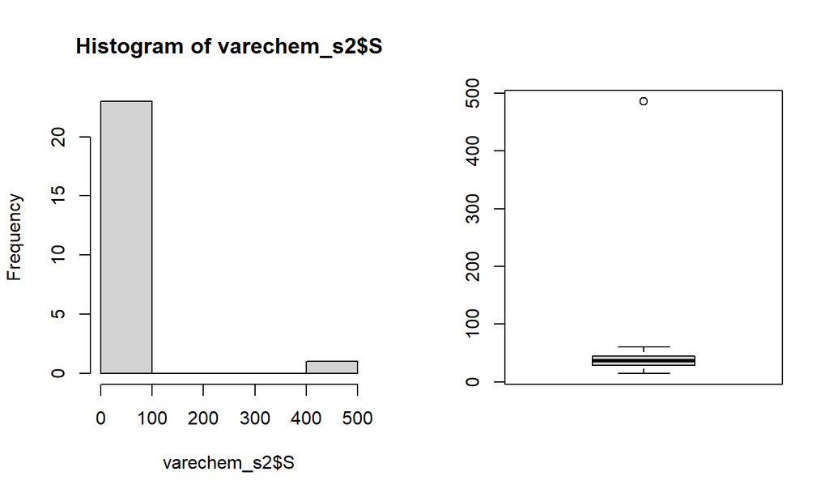

```r
par(mfrow=c(1,2))
hist(varechem_s2$S)
boxplot(varechem_s2$S)
```

## Visualize your data (4)

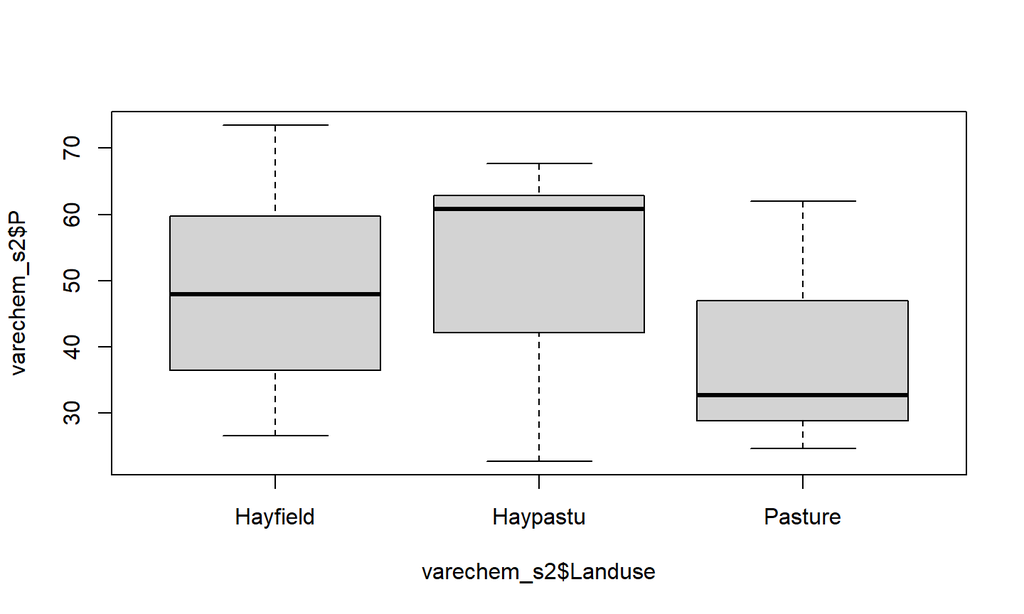

```r
boxplot(varechem_s2$P ~ varechem_s2$Landuse)
```

## Exercises: part 2 (25 min)

- Perform outlier analysis
  - for a univariate case: let’s consider S
  - for a multivariate case: let’s consider P~K here
    - do we have influential outliers?
    - **TIP**: olsrr-package

## Perform outlier analysis (1)

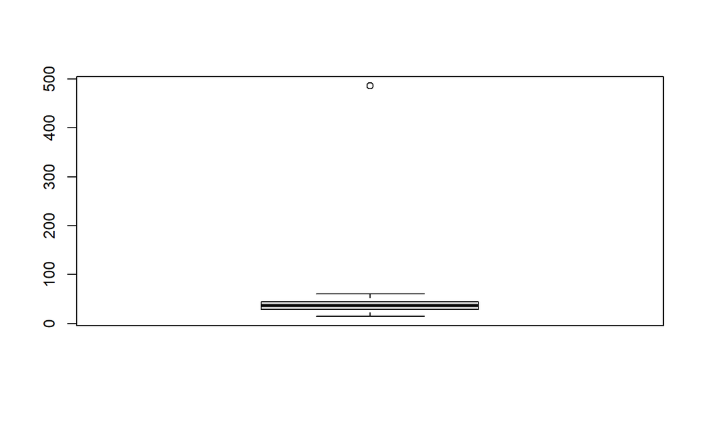

```r
# Univariate case
boxplot(varechem_s2$S) #We see one outlier
```

## Perform outlier analysis (2)

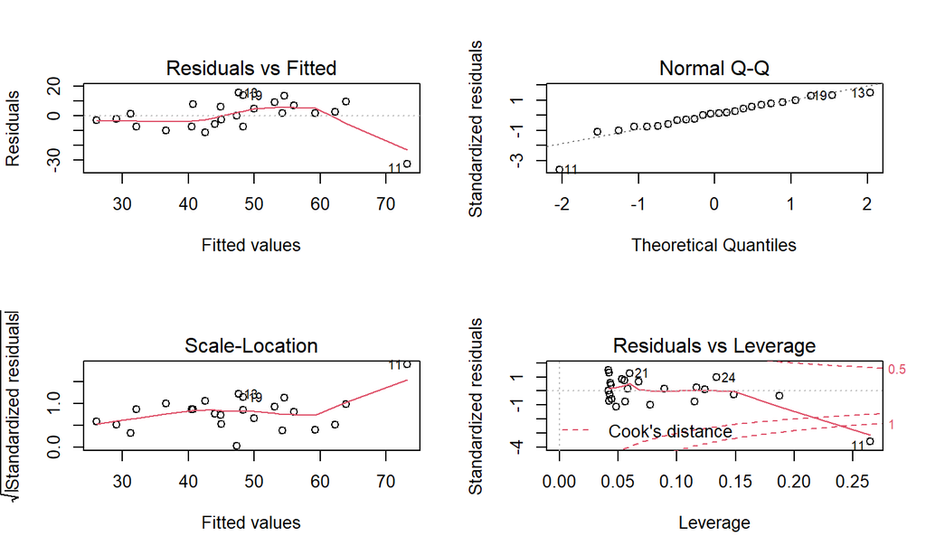

```r
# Multivariate case: specify a relationship between 2 (or more) variables
mod1<- lm(P~K,data=varechem_s2) #Therefore, we build a linear model (form y~x)
par(mfrow = c(2,2))
plot(mod1)
```

## Perform outlier analysis (3)

```r
# We'll perform an outlier analysis with the package olsrr
library(olsrr)
```

## Perform outlier analysis (4)

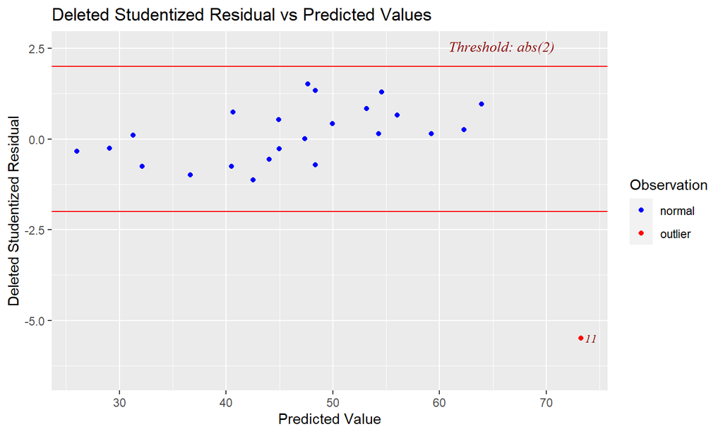

```r
# Check studentized deleted residuals to see if there are outliers
# Observation 11 is flagged as outlier
ols_plot_resid_stud_fit(mod1)
```

## Perform outlier analysis (5)

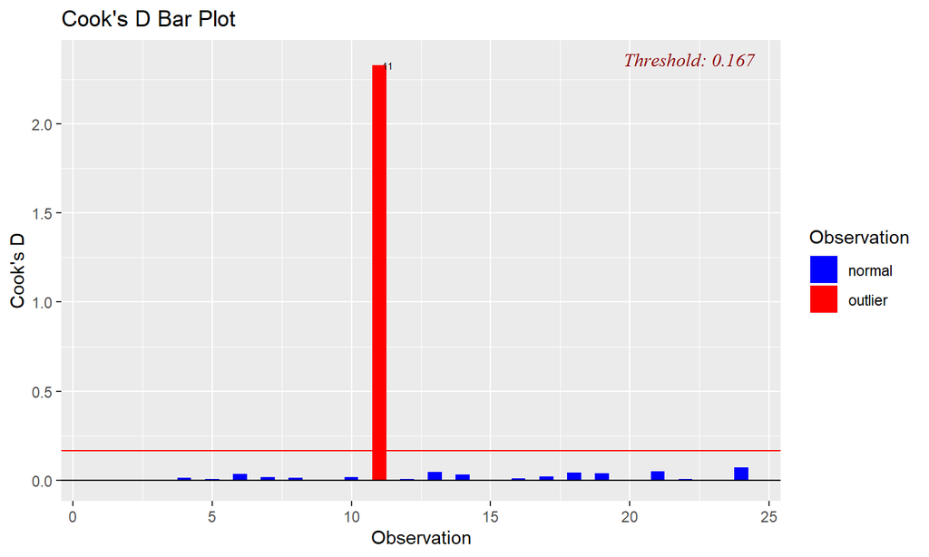

```r
# Now the question is, do these points have influence:
# We can clearly see that observation 11 has high influence
ols_plot_cooksd_bar(mod1)
```

## Perform outlier analysis (6)

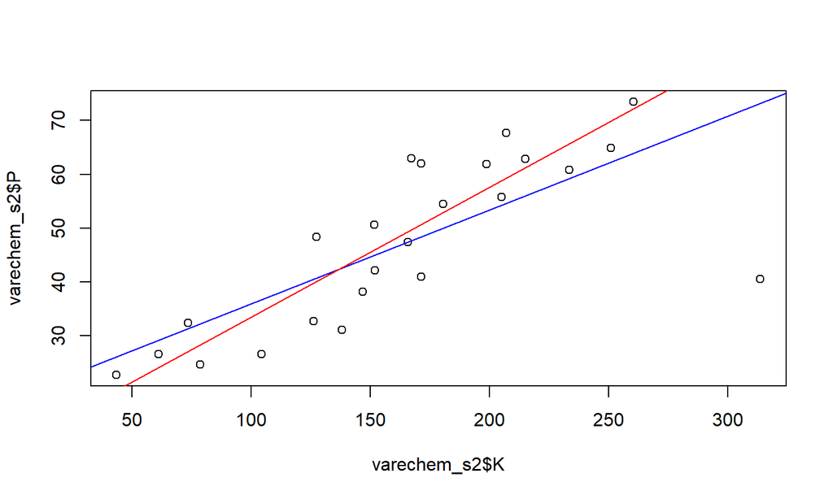

```r
plot(varechem_s2$K, varechem_s2$P)
abline(lm(P ~ K, data = varechem_s2), col = "blue")      #relationship with outlier
abline(lm(P ~ K, data = varechem_s2[-11,]), col = "red") #relationship without outlier
```

## Exercises: part 3 (25 min)

- Check distribution of variables
  - Is the data normally distributed?
  - Make a visual inspection for the variable Potassium **(K)** and Calcium **(Ca)**
  - Use a statistical test
- Apply transformations to normalize variables
  - Let’s do this for the variable Calcium **(Ca)**
- Apply transformations to linearize relationships
  - Do this for the relationship between Iron **(Fe)** and Zinc **(Zn)**

## Check distribution of variables (1)

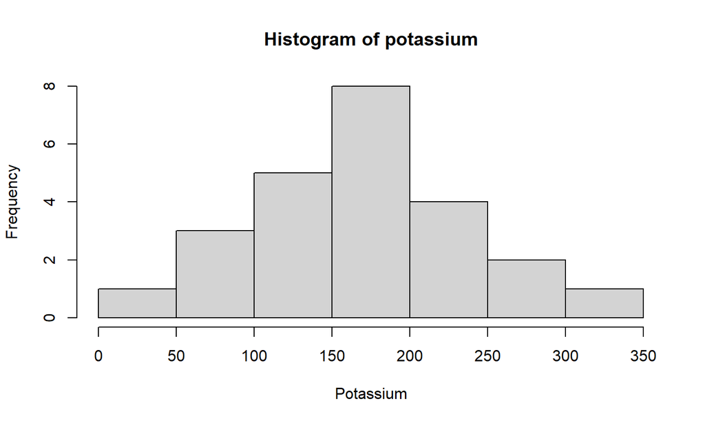

```r
# We can plot a histogram to visually check the data
hist(varechem_s2$K, xlab="Potassium",main="Histogram of potassium")
```

## Check distribution of variables (2)

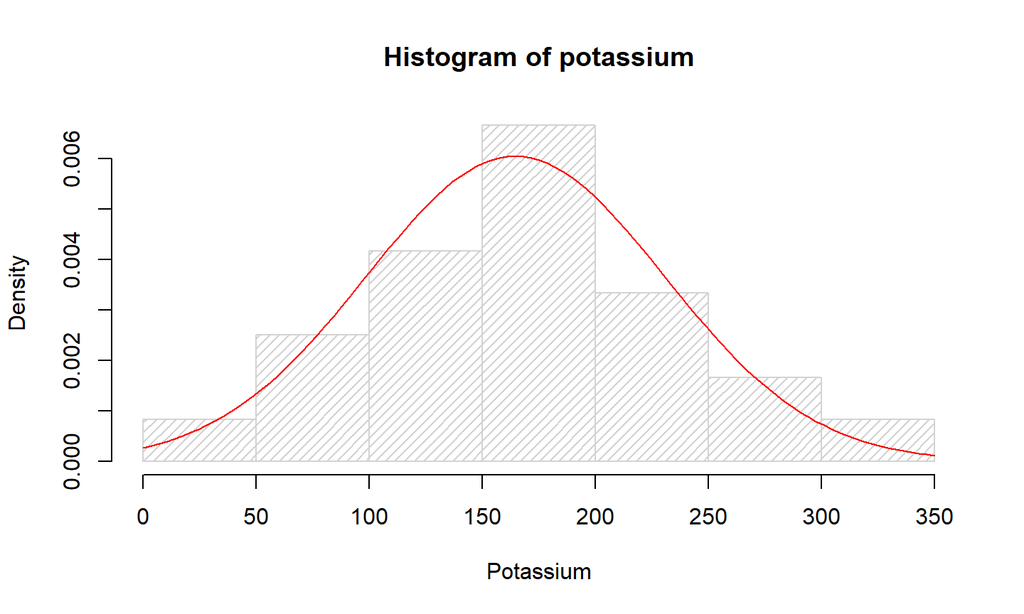

```r
# We can overlay the normal curve to have a reference
hist(varechem_s2$K, density=20, prob=TRUE, xlab="Potassium",main="Histogram of potassium")
curve(dnorm(x, mean=mean(varechem_s2$K), sd=sqrt(var(varechem_s2$K))),col="red", add=TRUE)
```

## Check distribution of variables (3)

```r
# We can also test for normality in a statistical way: shapiro-wilk test
# although NOT recommended over visual check as it is too strict! (see slides)
shapiro.test(varechem_s2$K)
```

```
##
##  Shapiro-Wilk normality test
##
## data:  varechem_s2$K
## W = 0.98547, p-value = 0.9719
```

```r
# p-value > 0.05 --> accept zero-hypotheses --> normal distribution
```

## Normalizing variables (1)

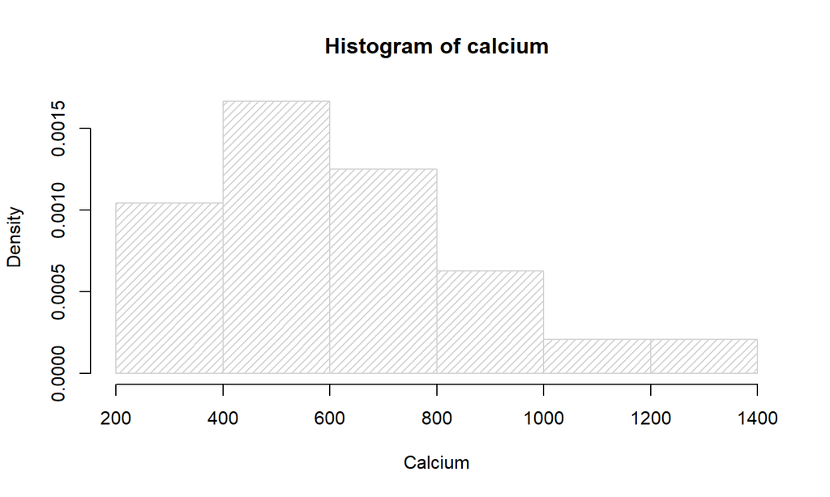

```r
# Look at a differen variable
# We see that this case is clearly positive skewed!
hist(varechem_s2$Ca, density=20, prob=TRUE, xlab="Calcium",main="Histogram of calcium")
```

## Normalizing variables (2)

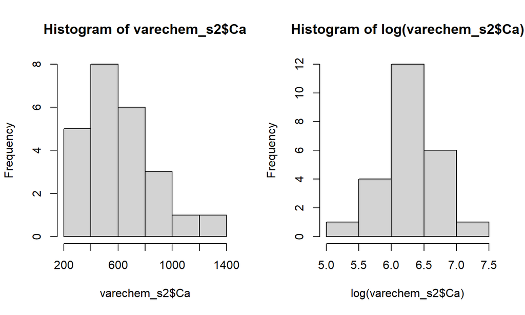

```r
par(mfrow=c(1,2))
hist(varechem_s2$Ca)
hist(log(varechem_s2$Ca)) #log transformation seemed to help
```

## Normalizing linear relationships (1)

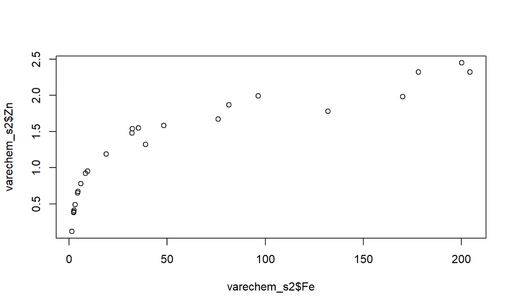

```r
par(mfrow=c(1,1))
plot(varechem_s2$Fe,varechem_s2$Zn)
```

## Normalizing linear relationships (2)

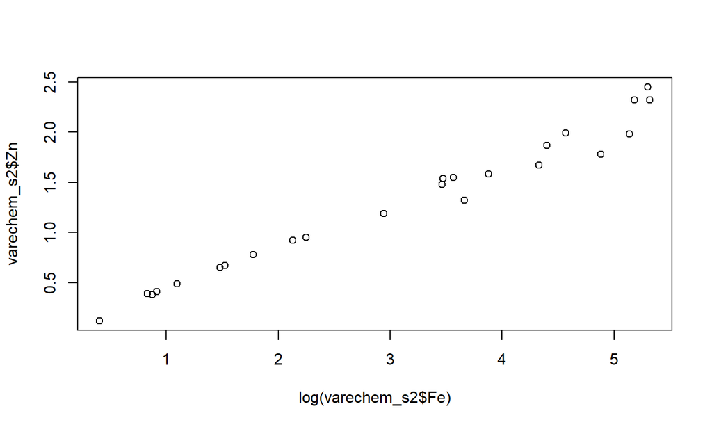

```r
par(mfrow=c(1,1))
plot(log(varechem_s2$Fe),varechem_s2$Zn)
```

## Assignment 2

Access the assignment:

```r
vignette("assignment-2", package = "edcpR")
```

Remember to upload everything before **October 27, 12 am (= at noon!)**.